# Noter - Lektion 8

Johan Ejstrud

2022-05-05

## Dates ([01:56](https://www.youtube.com/watch?v=O5AyEd4lNb0&t=116s))

- The package ‘lubridate’ ([cheat sheet](https://rawgit.com/rstudio/cheatsheets/main/lubridate.pdf)) makes working with dates a lot easier. It’s not part of the core tidyverse, so it has to be loaded explicitly.

```r
library(tidyverse)
library(lubridate)
```

- There are 3 kinds of time references: *date*, *time*, and *date-time*.

```r
tribble(
  ~`Date Time`,   ~Date,                  ~Time,
         now(), today(), hms::as_hms(Sys.time())
)
```

```
## # A tibble: 1 x 3
##   `Date Time`         Date       Time
##   <dttm>              <date>     <time>
## 1 2022-05-05 14:01:42 2022-05-05 14:01:42.173147
```

Notices that the 3 types are printed above the columns as `<dttm>`, `<date>`, and `<time>`.

- *times* are handled by the package [‘hms’](https://hms.tidyverse.org/reference/hms.html) which is similar to ‘lubridate’.

### From strings ([02:26](https://www.youtube.com/watch?v=O5AyEd4lNb0&t=146s))

When importing data, dates and times usually aren’t recognized, and are therefore represented as strings and numbers. Converting these, so R knows they are dates, makes our life easier.

- ‘lubridate’ has several functions combining the letters ‘y’ (year), ‘m’ (month), and ‘d’ (day) that can convert any date format, simply by writing the order of the components.

```r
ymd("2022-05-13")
```

```
## [1] "2022-05-13"
```

```r
mdy(05132022)
```

```
## [1] "2022-05-13"
```

```r
dmy("13th of May 2022")
```

```
## [1] "2022-05-13"
```

- For date-times, add ‘h’, ‘m’, and ‘s’ and seperate the date and time part with an ’_’.

```r
ymd_hms("2022-05-13 06:47:59")
```

```
## [1] "2022-05-13 06:47:59 UTC"
```

```r
dmy_hm("13-05-2022 06:47")
```

```
## [1] "2022-05-13 06:47:00 UTC"
```

### From several variables ([05:07](https://www.youtube.com/watch?v=O5AyEd4lNb0&t=307s))

Sometimes dates are split across several variables.

```r
library(nycflights13)

glimpse(flights)
```

```
## Rows: 336,776
## Columns: 19
## $ year           <int> 2013, 2013, 2013, 2013, 2013, 2013, 2013, 2013, 2013, 2~
## $ month          <int> 1, 1, 1, 1, 1, 1, 1, 1, 1, 1, 1, 1, 1, 1, 1, 1, 1, 1, 1~
## $ day            <int> 1, 1, 1, 1, 1, 1, 1, 1, 1, 1, 1, 1, 1, 1, 1, 1, 1, 1, 1~
## $ dep_time       <int> 517, 533, 542, 544, 554, 554, 555, 557, 557, 558, 558, ~
## $ sched_dep_time <int> 515, 529, 540, 545, 600, 558, 600, 600, 600, 600, 600, ~
## $ dep_delay      <dbl> 2, 4, 2, -1, -6, -4, -5, -3, -3, -2, -2, -2, -2, -2, -1~
## $ arr_time       <int> 830, 850, 923, 1004, 812, 740, 913, 709, 838, 753, 849,~
## $ sched_arr_time <int> 819, 830, 850, 1022, 837, 728, 854, 723, 846, 745, 851,~
## $ arr_delay      <dbl> 11, 20, 33, -18, -25, 12, 19, -14, -8, 8, -2, -3, 7, -1~
## $ carrier        <chr> "UA", "UA", "AA", "B6", "DL", "UA", "B6", "EV", "B6", "~
## $ flight         <int> 1545, 1714, 1141, 725, 461, 1696, 507, 5708, 79, 301, 4~
## $ tailnum        <chr> "N14228", "N24211", "N619AA", "N804JB", "N668DN", "N394~
## $ origin         <chr> "EWR", "LGA", "JFK", "JFK", "LGA", "EWR", "EWR", "LGA",~
## $ dest           <chr> "IAH", "IAH", "MIA", "BQN", "ATL", "ORD", "FLL", "IAD",~
## $ air_time       <dbl> 227, 227, 160, 183, 116, 150, 158, 53, 140, 138, 149, 1~
## $ distance       <dbl> 1400, 1416, 1089, 1576, 762, 719, 1065, 229, 944, 733, ~
## $ hour           <dbl> 5, 5, 5, 5, 6, 5, 6, 6, 6, 6, 6, 6, 6, 6, 6, 5, 6, 6, 6~
## $ minute         <dbl> 15, 29, 40, 45, 0, 58, 0, 0, 0, 0, 0, 0, 0, 0, 0, 59, 0~
## $ time_hour      <dttm> 2013-01-01 05:00:00, 2013-01-01 05:00:00, 2013-01-01 0~
```

- `make_date()` and `make_datetime()` converts several columns into date and date-time columns.

```r
flights %>%
  select(year, month, day, hour, minute) %>%
  mutate(date      = make_date(year, month, day),
         date_time = make_datetime(year, month, day, hour, minute))
```

```
## # A tibble: 336,776 x 7
##     year month   day  hour minute date       date_time
##    <int> <int> <int> <dbl>  <dbl> <date>     <dttm>
##  1  2013     1     1     5     15 2013-01-01 2013-01-01 05:15:00
##  2  2013     1     1     5     29 2013-01-01 2013-01-01 05:29:00
##  3  2013     1     1     5     40 2013-01-01 2013-01-01 05:40:00
##  4  2013     1     1     5     45 2013-01-01 2013-01-01 05:45:00
##  5  2013     1     1     6      0 2013-01-01 2013-01-01 06:00:00
##  6  2013     1     1     5     58 2013-01-01 2013-01-01 05:58:00
##  7  2013     1     1     6      0 2013-01-01 2013-01-01 06:00:00
##  8  2013     1     1     6      0 2013-01-01 2013-01-01 06:00:00
##  9  2013     1     1     6      0 2013-01-01 2013-01-01 06:00:00
## 10  2013     1     1     6      0 2013-01-01 2013-01-01 06:00:00
## # ... with 336,766 more rows
```

### Date components ([07:14](https://www.youtube.com/watch?v=O5AyEd4lNb0&t=434s))

- From a date or date-time variable we can get it’s components by using a number of functions that are named after the component they extract.

```r
date_time <- now()
date_time
```

```
## [1] "2022-05-05 14:01:43 -02"
```

```r
day(date_time)
```

```
## [1] 5
```

```r
month(date_time)
```

```
## [1] 5
```

```r
year(date_time)
```

```
## [1] 2022
```

```r
wday(date_time) # Day of week
```

```
## [1] 5
```

```r
wday(date_time, label = TRUE) # As string instead of number
```

```
## [1] Thu
## Levels: Sun < Mon < Tue < Wed < Thu < Fri < Sat
```

```r
yday(date_time) # Day of year
```

```
## [1] 125
```

These functions make it easy to create new variables after we have created the date-time variable:

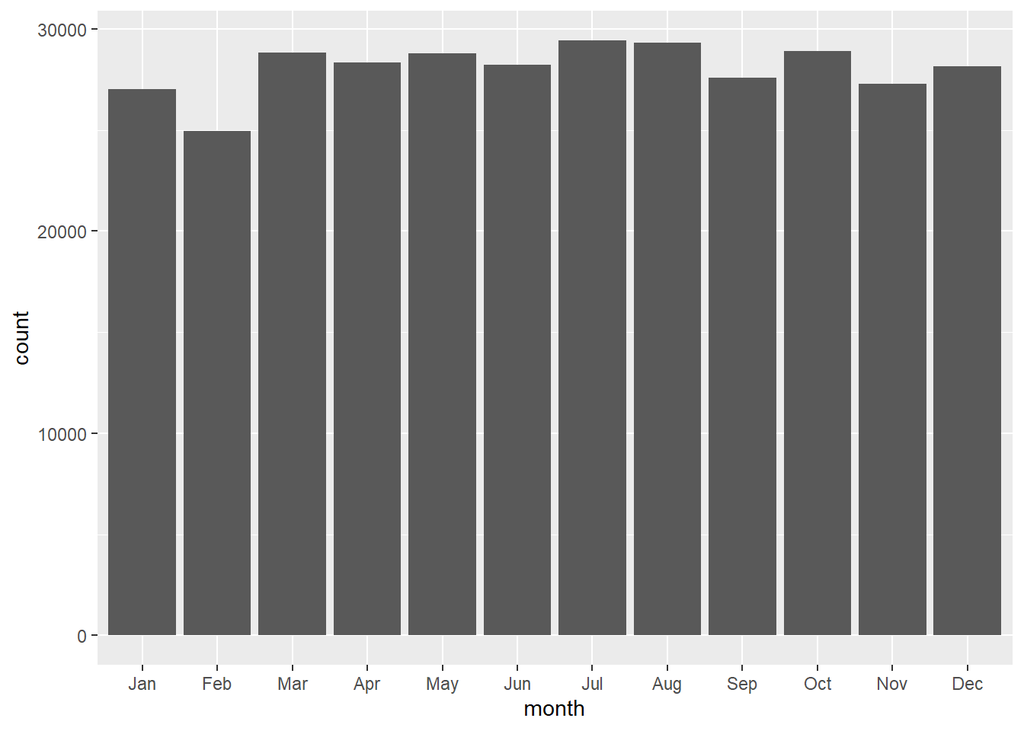

```r
flights %>%
  mutate(month = month(time_hour, label = TRUE)) %>%
  ggplot(aes(x = month)) +
    geom_bar()
```

### Timezones ([09:55](https://www.youtube.com/watch?v=O5AyEd4lNb0&t=595s))

- Functions dealing with dates have a `tz =` argument that can change the time zone.

```r
now() # Default is computer's system time zone
```

```
## [1] "2022-05-05 14:01:44 -02"
```

```r
now(tz = "America/Nuuk")
```

```
## [1] "2022-05-05 14:01:44 -02"
```

```r
now(tz = "Europe/Copenhagen")
```

```
## [1] "2022-05-05 18:01:44 CEST"
```

## Factors ([11:17](https://www.youtube.com/watch?v=O5AyEd4lNb0&t=677s))

- Factors are useful for variables that only have a certain number of values, and that might have a non-alphabetic order.

If we just make a list, R doesn’t know that these values have a certain order.

```r
days <- c("Monday", "Tuesday", "Wednesday", "Thursday")

sort(days)
```

```
## [1] "Monday"    "Thursday"  "Tuesday"   "Wednesday"
```

Instead, we make a factor:

```r
weekdays <- c("Monday",
              "Tuesday",
              "Wednesday",
              "Thursday",
              "Friday",
              "Saturday",
              "Sunday")

days2 <- factor(days, levels = weekdays)

sort(days2)
```

```
## [1] Monday    Tuesday   Wednesday Thursday
## Levels: Monday Tuesday Wednesday Thursday Friday Saturday Sunday
```

The values are now ordered, and we see all possible values.

This also saves us, if we make a spelling mistake.

```r
factor(c("Monday", "Frdiay", "Sonday"), levels = weekdays)
```

```
## [1] Monday <NA>   <NA>
## Levels: Monday Tuesday Wednesday Thursday Friday Saturday Sunday
```

### Reordering factors ([13:39](https://www.youtube.com/watch?v=O5AyEd4lNb0&t=819s))

When making visualizations it’s often useful to reorder factors.

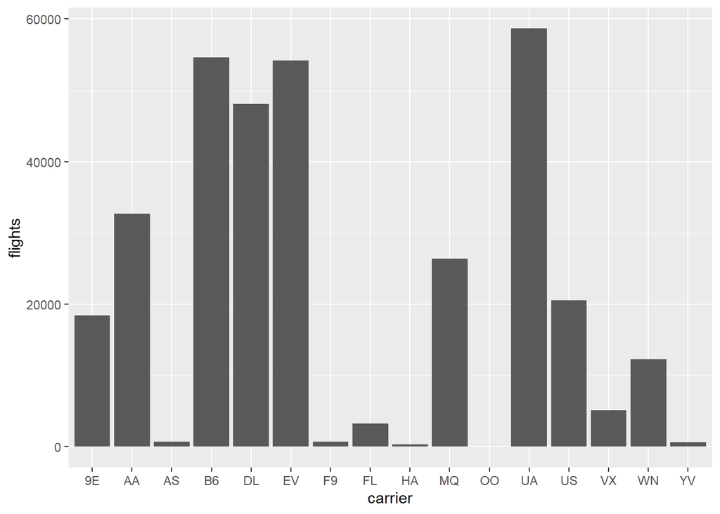

```r
summary <-
  flights %>%
  group_by(carrier) %>%
  summarise(flights = n())

ggplot(summary, aes(carrier, flights)) +
  geom_bar(stat = "identity")
```

- Use `fct_reorder()` to reorder a factor by another variable.

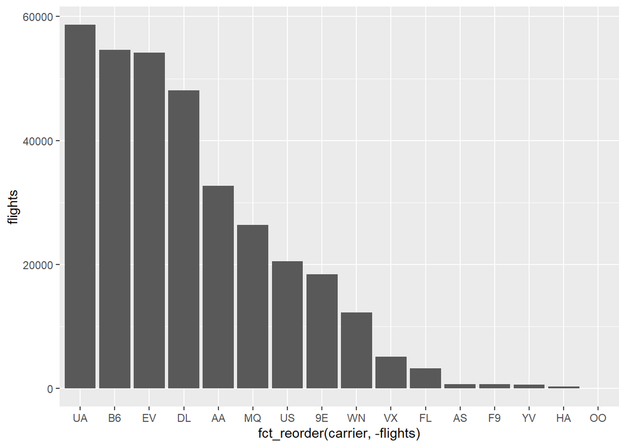

```r
ggplot(summary, aes(fct_reorder(carrier, -flights), flights)) +
  geom_bar(stat = "identity")
```

### Modifying levels ([15:41](https://www.youtube.com/watch?v=O5AyEd4lNb0&t=941s))

- Use `fct_recode()` to change the levels of a factor.

```r
diamonds %>%
  count(clarity)
```

```
## # A tibble: 8 x 2
##   clarity     n
##   <ord>   <int>
## 1 I1        741
## 2 SI2      9194
## 3 SI1     13065
## 4 VS2     12258
## 5 VS1      8171
## 6 VVS2     5066
## 7 VVS1     3655
## 8 IF       1790
```

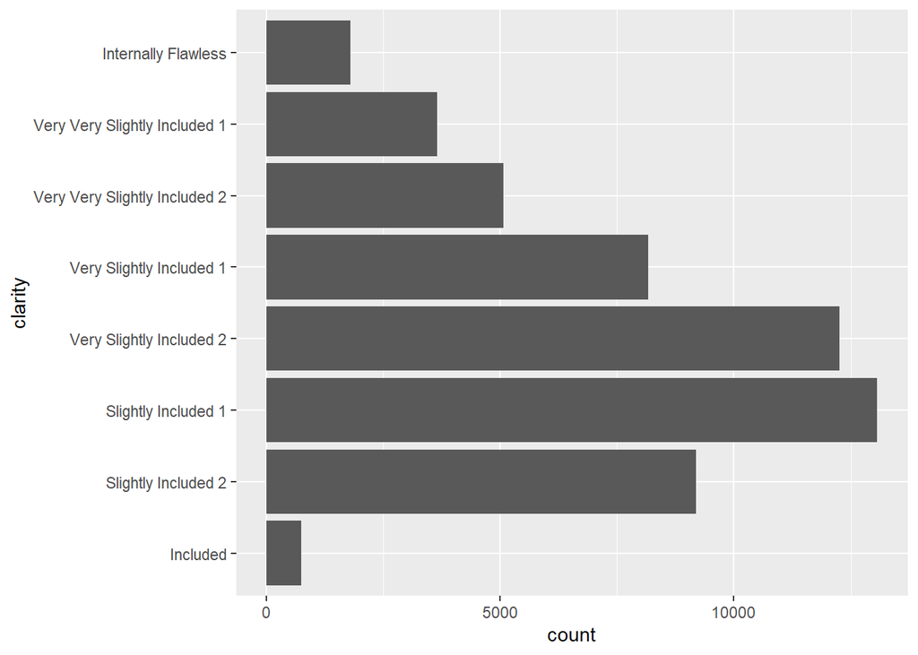

```r
diamonds %>%
  mutate(clarity = fct_recode(clarity,
                              "Internally Flawless" = "IF",
                              "Included" = "I1",
                              "Slightly Included 1" = "SI1",
                              "Slightly Included 2" = "SI2",
                              "Very Slightly Included 1" = "VS1",
                              "Very Slightly Included 2" = "VS2",
                              "Very Very Slightly Included 1" = "VVS1",
                              "Very Very Slightly Included 2" = "VVS2")
         ) %>%
  ggplot(aes(clarity)) +
    geom_bar() +
    coord_flip()
```